# Соревнование: San Francisco Crime Classification

*Given time and location, you must predict the category of crime that occurred. Kaggle is hosting this competition for the machine learning community to use for fun and practice.*

https://www.kaggle.com/c/sf-crime

Этот ноутбук структурирован таким образом, чтобы облегчить совместную работу над соревнованием. За некоторыми исключениями, каждый участник работает только в разделе 4. При этом ни одна из строк кода любого из разделов не является постоянной, если в ней нет необходимости, ее стоит исключить, если один из участников написал полезный код, который может пригодится остальным, то этот когда имеет смысл перенести из персонального раздела в общие. Ноутбук имеет следующую структуру:

1. Подготовка работы. Загрузка библиотек и настройка отображения
2. Загрузка и очистка данных
3. Общие функции
4. Персональный раздел
5. Модель на тестовой выборке

### 1. Подготовка работы. Загрузка библиотек и настройка отображения

Импорты и настройки, которые необходимы для шаблона.

```python
import pandas as pd
import numpy as np
import matplotlib.pyplot as plt
from sklearn.cross_validation import KFold, cross_val_score, train_test_split
from sklearn.preprocessing import LabelEncoder, OneHotEncoder, StandardScaler
from sklearn.metrics import log_loss
import time
import datetime
import csv

%matplotlib inline
```

### 2. Загрузка, очистка данных. Общие константы

Обучающая и тренировочная выборки надоходятся в папке `data`.

```python
#train = pd.read_csv('./data/train.csv')
```

```python
workspace_id='5992394bdb394322a51e79f28c4734a2',
authorization_token='9753e7b65b2f4431894c336260ad2c58',
#workspace_id='my_ws_id',
#authorization_token='my_token',

# AZURE DATA LOADING
# read training and test datasets
from azureml import Workspace

ws = Workspace(
    workspace_id=workspace_id,
    authorization_token=authorization_token,
    endpoint='https://studioapi.azureml.net'
)

train = ws.datasets['SF_crimes_train.csv'].to_dataframe()
test = ws.datasets['SF_crimes_test.csv'].to_dataframe()
```

#### 2.1. Очистка данных

В то время, как в `train` находятся сырые данные, `X_train` содержит те же колонки, что и `test`, поэтому многие преобразования над обеими переменными могут выполняться одной функцией.

```python
# необходимо принять волевое решение, что делать с данными у которых левые координаты?
# пока их исключаем
train = train[train.Y < 40]
# эти колонки содержаться в обучающей выборке, включая те, которых нет в тестовой
train_features = train.columns.tolist()
# эти колонки содержаться в тестовой выборке
test_features = ['Dates', 'DayOfWeek', 'PdDistrict', 'Address', 'X', 'Y']
# теперь X_train с правильными колонками
X_train = train[test_features]

# конвертер категорий в числовые признаки
category_enc = LabelEncoder()
category_enc.fit(train.Category)
y_train = category_enc.transform(train.Category)

# список происшествий, колонки для файла с результатами
#out_features = pd.read_csv('./data/sampleSubmission.csv', nrows=1, index_col='Id').columns.tolist()
out_features = ['ARSON','ASSAULT','BAD CHECKS','BRIBERY','BURGLARY','DISORDERLY CONDUCT','DRIVING UNDER THE INFLUENCE',
                'DRUG/NARCOTIC','DRUNKENNESS','EMBEZZLEMENT','EXTORTION','FAMILY OFFENSES','FORGERY/COUNTERFEITING','FRAUD',
                'GAMBLING','KIDNAPPING','LARCENY/THEFT','LIQUOR LAWS','LOITERING','MISSING PERSON','NON-CRIMINAL',
                'OTHER OFFENSES','PORNOGRAPHY/OBSCENE MAT','PROSTITUTION','RECOVERED VEHICLE','ROBBERY','RUNAWAY',
                'SECONDARY CODES','SEX OFFENSES FORCIBLE','SEX OFFENSES NON FORCIBLE','STOLEN PROPERTY','SUICIDE',
                'SUSPICIOUS OCC','TREA','TRESPASS','VANDALISM','VEHICLE THEFT','WARRANTS','WEAPON LAWS']
```

#### 2.2. Общие константы

Константы, которые используются для обработки данных.

```python
# данные
train_rows = X_train.shape[0]

# количество классов происшествий
classes = len(out_features)

# другие
random_state = 19
```

### 3. Общие функции

```python
class Timer(object):
    def __init__(self, show_borders=False):
        self.start_time = datetime.datetime.now()
        self.show_borders=False
        self.finish_time = None
        self.duration = None
    def finish(self, msg = '', verbose=True):
        self.finish_time = datetime.datetime.now()
        self.duration = self.finish_time - self.start_time
        self.msg = msg
        if msg != '':
            print ('%s'%self.msg)
        if verbose:
            if self.show_borders:
                print ('Duration: %s Start: %s Finish: %s  \n'%(self.duration, self.start_time, self.finish_time))
            else:
                print ('Duration: %s\n'%(self.duration))
    def __str__(self):
        return 'Duration: %s Start: %s Finish: %s  \n'%(self.duration, self.start_time, self.finish_time)


def add_col(X, X_add):
    assert X.shape[0] == X_add.shape[0]
    X_add.index = X.index
    return pd.concat([X, X_add], axis=1, join_axes=[X.index])


def score_model(clf, X, y, use_cross_val=True, random_state=0, n_folds=5, scoring='log_loss'):
    t = Timer()

    if use_cross_val:
        cv = KFold(n=train_rows, n_folds=5, shuffle=True, random_state=random_state)
        score = cross_val_score(my_awesome_clf, X, y, cv=cv, scoring='log_loss').mean()

    else:
        X_train, X_test, y_train, y_test = train_test_split(X, y,
                                          test_size=0.3,
                                          random_state=random_state)
        clf.fit(X_train, y_train)
        pred = clf.predict_proba(X_test)
        score = log_loss(y_test, pred)

    t.finish()
    print ('LogLoss score:', score)
    return score

def score_split(clf, X, y, random_state = 0, n_folds=5, scoring='log_loss'):
    return score_model(clf, X, y, use_cross_val = False,
                       random_state = random_state, n_folds=n_folds, scoring=scoring)

def score_cross(clf, X, y, random_state = 0, n_folds=5, scoring='log_loss'):
    return score_model(clf, X, y, use_cross_val = True,
                       random_state = random_state, n_folds=n_folds, scoring=scoring)

def score_xgb(clf, X, y, random_state = 0, eval_metric='mlogloss', early_stopping_rounds=10, verbose=True):

    X_train, X_test, y_train, y_test = train_test_split(X, y,
                                      test_size=0.2,
                                      random_state=random_state)

    t = Timer()

    clf.fit(X_train, y_train, eval_metric=eval_metric,
                              eval_set=[(X_test, y_test)],
                              early_stopping_rounds=early_stopping_rounds,
                              verbose=verbose)

    t.finish()
    return clf


def test_feature(X, y, feature_data, n_estimators = 20, columns = 'new_feature',
                         random_state = 0, eval_metric='mlogloss', verbose=True):

    assert X.shape[0] == feature_data.shape[0]
    assert X.shape[0] == y.shape[0]

    clf_xgb = xgboost.XGBClassifier(max_depth=10,
                            n_estimators=n_estimators,
                            learning_rate=0.05,
                            nthread=16,
                            seed=random_state,
                            silent=False)

    #test without feature
    X_train, X_test, y_train, y_test = train_test_split(X, y,
                                      test_size=0.2,
                                      random_state=random_state)

    res1 = clf.fit(X_train, y_train, eval_metric=eval_metric,
                              eval_set=[(X_test, y_test)],
                              early_stopping_rounds=early_stopping_rounds,
                              verbose=verbose)

    X_add = add_col(X, pd.DataFrame(feature_data, columns=columns))

    #test with feature
    X_train, X_test, y_train, y_test = train_test_split(X_add, y,
                                      test_size=0.2,
                                      random_state=random_state)

    res2 = clf.fit(X_train, y_train, eval_metric=eval_metric,
                              eval_set=[(X_test, y_test)],
                              early_stopping_rounds=early_stopping_rounds,
                              verbose=verbose)

    return res1, res2


# расчет и сохранение предсказаний на тестовой выборке в файл по частям в случае нехватки памяти
def save_partial_predictions(clf, nrows, path_to_data, path_to_ans, transform_func):
    chunk_size = 100000
    done = 0
    first_iter = True
    open(path_to_ans, 'w+').close()
    while done < nrows:
        print('Done: {0}/{1}'.format(done, nrows))
        test_data = pd.read_csv(path_to_data,
                                skiprows=xrange(1, done+1), # 1 - to read header
                                nrows=chunk_size)
        start_id = test_data['Id'][0]
        done += chunk_size
        print('start id: ', start_id)
        test_data = transform_func(test_data)
        proba = clf.predict_proba(test_data)
        ans = to_ans_format(proba, start_id)
        ans.to_csv(path_to_ans, mode='a', index=False, header=first_iter)
        first_iter = False
    print('Done')

# сохранение предсказаний в файл
def save_predictions(output_name, predictions, index, columns, float_format='%.6f'):
    df = pd.DataFrame(predictions, index=index, columns=columns)
    df.index.name = 'Id'
    df.to_csv(output_name, compression='gzip', float_format=float_format)
```

### 4. Персональный раздел.

Место для творчества. В этом пункте можно творить что угодно!

#### 4.1. Мои импорты

Устанавливаем xgboost (нужно только для Azure при рестарте сессии)

```python
# version 1 - xgboost from pip
!pip install --pre xgboost
```

```
    100% |################################| 753kB 509kB/s
  Running setup.py bdist_wheel for xgboost ... - \ | / - \ | / - \ | / - done
You are using pip version 8.0.3, however version 8.1.0 is available.
```

```python
# version 2 - xgboost from github
!git clone --recursive https://github.com/dmlc/xgboost ~/xgb_copy
!cd ~/xgb_copy; make -j4
!pip install --upgrade -e ~/xgb_copy/python-package/
```

[output not shown]

[output cut: 89 more lines]

[output not shown]

```python
import xgboost
from xgboost import plot_importance
```

#### 4.2. Мои константы

Все мои клевые константы находятся здесь.

```python
# то, чем пользуюcь только я
random_state = 42
n_jobs = 4
learning_rate = 0.1
```

#### 4.3. Мои функции

##### Unwrap PdDistricts and WeekDays, convert Dates

```python
def transform_enc(X):
    t = Timer()
    new_X = X.copy()

    new_X['DateTime'] = pd.to_datetime(new_X.Dates)
    new_X['Year'] = new_X.DateTime.apply(lambda x: x.year)
    new_X['Month'] = new_X.DateTime.apply(lambda x: x.month)
    new_X['Day'] = new_X.DateTime.apply(lambda x: x.day)
    new_X['Hour'] = new_X.DateTime.apply(lambda x: x.hour)
    new_X['Minute'] = new_X.DateTime.apply(lambda x: x.minute)

    le = LabelEncoder()
    new_X['PdDistrict'] = le.fit_transform(new_X['PdDistrict'])
    new_X['DayOfWeek'] = le.fit_transform(new_X['DayOfWeek'])
    new_X['Year'] = le.fit_transform(new_X['Year'])
    new_X['Month'] = le.fit_transform(new_X['Month'])
    new_X['Day'] = le.fit_transform(new_X['Day'])
    new_X['Hour'] = le.fit_transform(new_X['Hour'])
    new_X['Minute'] = le.fit_transform(new_X['Minute'])

    new_X.drop(['Address', 'Dates', 'DateTime'], axis=1, inplace=True)

    t.finish('transform_enc finished')

    return new_X

def tune_minutes(X):
    t = Timer()
    X['minute_0'] = X.Minute.apply(lambda x: 1 if x==0 else 0)
    X['minute_1'] = X.Minute.apply(lambda x: 1 if x==1 else 0)
    X['minute_0_30'] = X.Minute.apply(lambda x: 1 if x in [0,30] else 0)
    X['minute_every_15'] = X.Minute.apply(lambda x: 1 if x in [0,15,30,45] else 0)
    X['minute_every_10'] = X.Minute.apply(lambda x: 1 if x%10==0 else 0)
    X['minute_every_5'] = X.Minute.apply(lambda x: 1 if x%5==0 else 0)
    X.drop(['Minute'], axis=1, inplace=True)
    t.finish('minutes done')
    return X

def get_streets(street):
    if street.find('/') != -1:
        return [part.strip() for part in street.split('/')][0]
    pos = street.find('Block of ')
    if pos != -1:
        return street[pos+9:]
    return street

def SkipSeldomAddresses(X, threshold):
    s = X.Address.value_counts()
    good_addr = s[s > threshold].keys()
    filtered_addresses = X.Address.copy()
    filtered_addresses[X.Address.isin(good_addr) == False] = 'rare address'
    return filtered_addresses

def CoordToGridNum(X, grid_params, gridsize = 60):
    t = Timer()

    cX_step = (grid_params['max_X'] - grid_params['min_X']) / float(gridsize)
    cY_step = (grid_params['max_Y'] - grid_params['min_Y']) / float(gridsize)

    gridcellnums = np.zeros(X.shape[0])
    for i, index in enumerate(X.index):
        cX = X.ix[index, 'X']
        cY = X.ix[index, 'Y']
        X_cell = int((cX - grid_params['min_X']) / cX_step)
        Y_cell = int((cY - grid_params['min_Y']) / cY_step)
        if (X_cell + gridsize * Y_cell < 0):
            gridcellnums[i] = -1
        if (X_cell + gridsize * Y_cell > gridsize * gridsize - 1):
            gridcellnums[i] = -2
        else:
            gridcellnums[i] = X_cell + gridsize * Y_cell
        if i%100000 == 0:
            print (i, end=" ")
    t.finish('grid is done')
    return gridcellnums

def is_corner(addr):
    if addr.find('/') != -1:
        return 1
    return 0

def get_transform_params(train, test):

    all_addr = pd.concat([train[['Address']], test[['Address']]])
    all_streets = all_addr['Address'].apply(lambda x: get_streets(x))

    addr_encoder = LabelEncoder()
    addr_encoder.fit(all_addr['Address'])

    street_encoder = LabelEncoder()
    street_encoder.fit(all_streets)

    grid_params = {}
    grid_params['min_X'] = np.min([train.X[train.Y < 40].min(), test.X[test.Y < 40].min()]) - 0.0001
    grid_params['max_X'] = np.min([train.X[train.Y < 40].max(), test.X[test.Y < 40].max()]) + 0.0001
    grid_params['min_Y'] = np.min([train.Y[train.Y < 40].min(), test.Y[test.Y < 40].min()]) - 0.0001
    grid_params['max_Y'] = np.min([train.Y[train.Y < 40].max(), test.Y[test.Y < 40].max()]) + 0.0001

    return addr_encoder, street_encoder, grid_params


def full_transform(data, addr_encoder, street_encoder, grid_params):

    t = Timer()

    mod_data = transform_enc(data)
    mod_data = tune_minutes(mod_data)

    mod_data['Hour_0_12'] = mod_data['Hour'].apply(lambda x: 1 if x in [0,12] else 0)
    mod_data['Hour_sin_neg4'] = mod_data['Hour'].apply(lambda x: np.sin(-np.pi/12. * (x - 4)))

    if (mod_data.index.name == 'Id'):
        mod_data.drop(['Id'], axis=1, inplace=True)

    mod_data['Corner'] = data.Address.apply(lambda x: is_corner(x))

    gridCellNums = CoordToGridNum(data, grid_params, gridsize = 60)
    mod_data['gridCellNum'] = gridCellNums

    mod_data['Address'] = addr_encoder.transform(data['Address'])
    mod_data['Street'] = data['Address'].apply(lambda x: get_streets(x))
    mod_data['Street'] = street_encoder.transform(mod_data['Street'])

    t.finish('Data was transformed')

    return mod_data
```

#### 4.4. Моя модель

1. Лог.регрессия показала плохие результаты (по сравнению с xgboost) на любых наборах признаков ( > 2.6).
2. XGBoost дает отличный результат
3. Геометрическая сетка по координатам (чем больше тем лучше, но медленее, пока 60x60) дает незначительное улучшение
4. Осмысленная разбивка по минутам (0-ая, 1-ая, 0/30-ая, 0/15/30/45, m%5==0) значимо улучшает модель
5. Небольшие улучшения дают новые фичи в часах: а) 0/12 - время регистрации для нек.категорий чаще б) Специальная синусоида по часам для проституции (ночью - пик, днем - спад)
6. Некоторые преступления совершаются только на перекрестках (проституция и др.) - выделение перекрестка дает небольшое улучшение
7. Выделение улицы дает улучшение

Далее:

1. Применить PCA
2. Тюнить xgboost
3. Событие с несколькими преступлениями

Потенциал:

1. кластеризация районов по координатам
2. кластеризация по ДТП (выделение дорожной сетки)

Тестирование: 20 деревьев <= 2.704, 500 <= 2.204

```python
addr_encoder, street_encoder, grid_params = get_transform_params(X_train, test)
mod_train = full_transform(X_train, addr_encoder, street_encoder, grid_params)
```

```
transform_enc finished
Duration: 0:00:30.332866

minutes done
Duration: 0:00:04.915220

0 100000 200000 300000 400000 500000 600000 700000 800000 grid is done
Duration: 0:00:17.443875

Data was transformed
Duration: 0:01:09.035482
```

```python
mod_train.columns
```

```
Index(['DayOfWeek', 'PdDistrict', 'X', 'Y', 'Year', 'Month', 'Day', 'Hour', 'minute_0', 'minute_1', 'minute_0_30', 'minute_every_15', 'minute_every_10', 'minute_every_5', 'Hour_0_12', 'Hour_sin_neg4', 'Corner', 'gridCellNum', 'Address', 'Street'], dtype='object')
```

```python
t = Timer()
clf = xgboost.XGBClassifier(max_depth=10,
                            n_estimators=500,
                            learning_rate=0.05,
                            nthread=16,
                            seed=random_state,
                            silent=False)

clf.fit(mod_train, y_train, verbose=True)
t.finish()
```

```
Duration: 1:38:49.386376
```

```python
clf.get_params()
```

```
{'base_score': 0.5,
 'colsample_bylevel': 1,
 'colsample_bytree': 1,
 'gamma': 0,
 'learning_rate': 0.05,
 'max_delta_step': 0,
 'max_depth': 10,
 'min_child_weight': 1,
 'missing': None,
 'n_estimators': 500,
 'nthread': 16,
 'objective': 'binary:logistic',
 'reg_alpha': 0,
 'reg_lambda': 1,
 'scale_pos_weight': 1,
 'seed': 42,
 'silent': False,
 'subsample': 1}
```

### Testing

```python
# xgboost со всеми датами и округами, плюс X,Y, плюс Адрес и улица, плюс тюнинг минут
clf_xgb = xgboost.XGBClassifier(max_depth=10,
                            n_estimators=2000,
                            learning_rate=0.05,
                            nthread=16,
                            seed=random_state,
                            silent=False)
score_xgb(clf_xgb, mod_train, y_train, early_stopping_rounds=20)
```

```
Will train until validation_0 error hasn't decreased in 20 rounds.
```

```
Duration: 1:06:27.554927
```

[output not shown]

```
XGBClassifier(base_score=0.5, colsample_bylevel=1, colsample_bytree=1,
       gamma=0, learning_rate=0.05, max_delta_step=0, max_depth=10,
       min_child_weight=1, missing=None, n_estimators=2000, nthread=16,
       objective='multi:softprob', reg_alpha=0, reg_lambda=1,
       scale_pos_weight=1, seed=42, silent=False, subsample=1)
```

### tune Hours

```python
mod_train['Hour_0_12'] = mod_train['Hour'].apply(lambda x: 1 if x in [0,12] else 0)
mod_train['Hour_sin_neg4'] = mod_train['Hour'].apply(lambda x: np.sin(-np.pi/12. * (x - 4)))
```

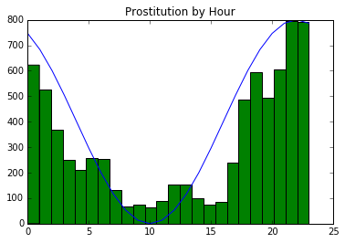

```python
t = np.sin(-np.pi/12. * (np.array(range(24)) - 4)) * 400 + 400
plt.plot(t)
r = mod_train[train.Category == 'PROSTITUTION'].Hour
plt.hist(r, bins=24)
plt.title('Prostitution by Hour')
```

```python
mod_train.columns
```

```
Index(['DayOfWeek', 'PdDistrict', 'X', 'Y', 'Year', 'Month', 'Day', 'Hour', 'minute_0', 'minute_1', 'minute_0_30', 'minute_every_15', 'minute_every_10', 'minute_every_5', 'Address', 'Street', 'Hour_0_12', 'Hour_sin_neg4'], dtype='object')
```

#### Оценка пользы признака (синусоида) в осмысленных значениях

```python
mod_train.columns
```

```
Index(['DayOfWeek', 'PdDistrict', 'X', 'Y', 'Year', 'Month', 'Day', 'Hour', 'minute_0', 'minute_1', 'minute_0_30', 'minute_every_15', 'minute_every_10', 'minute_every_5', 'Hour_0_12', 'Hour_sin_neg4', 'Corner', 'gridCellNum', 'Address', 'Street'], dtype='object')
```

```python
X_train2, X_test2, y_train2, y_test2 = train_test_split(mod_train, y_train,
                                          test_size=0.3,
                                          random_state=random_state)

clf_xgb2 = xgboost.XGBClassifier(max_depth=10,
                            n_estimators=20,
                            learning_rate=0.05,
                            nthread=16,
                            seed=random_state,
                            silent=False)

clf_xgb2.fit(X_train2, y_train2, verbose=1)

X_test3 = X_test2[y_test2 == 23]

pred = clf_xgb2.predict_proba(X_test3)
```

```python
no_sin_data = mod_train.drop(['Hour_sin_neg4'], axis=1)

X_train2, X_test2, y_train2, y_test2 = train_test_split(no_sin_data, y_train,
                                          test_size=0.3,
                                          random_state=random_state)

clf_xgb3 = xgboost.XGBClassifier(max_depth=10,
                            n_estimators=20,
                            learning_rate=0.05,
                            nthread=16,
                            seed=random_state,
                            silent=False)

clf_xgb3.fit(X_train2, y_train2, verbose=True)

X_test3 = X_test2[y_test2 == 23]

pred_no_sin = clf_xgb3.predict_proba(X_test3)
```

```python
log1 = log_loss(np.ones(pred.shape[0]), pred[:, 23] / pred[:, 23].max() - 0.001)
res1 = (pred[:, 23] / pred[:, 23].max() > 0.5).sum()
print (res1, pred.shape[0], log1)
```

```
1004 2301 0.756763908624
```

```python
pred[:, 23].max()
```

```
0.40934223
```

```python
log2 = log_loss(np.ones(pred_no_sin.shape[0]), pred_no_sin[:, 23] / pred[:, 23].max() - 0.001)
res2 = (pred_no_sin[:, 23] / pred[:, 23].max() > 0.5).sum()
print (res2, pred_no_sin.shape[0], log2)
```

```
982 2301 0.755679074238
```

Таким образом, с синусоидой мы подняли кол-во предсказанных проституток с 982 до 1004 (из 2301)

### experiments

```python
pop = train.Category.value_counts()[:2]
print (pop.keys())
```

```
Index(['LARCENY/THEFT', 'OTHER OFFENSES'], dtype='object')
```

```python
wd = train.DayOfWeek.value_counts()
```

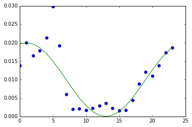

```python
hours = mod_train.Hour.value_counts()
#r = mod_train.Hour[(train.Category == cat) & (train.DayOfWeek == wd)]
s = []
for h in range(24):
    s.append(mod_train.Hour[(train.Category == 'PROSTITUTION') & (mod_train.Hour == h)].shape[0] / float(hours[h]))

plt.plot(s, 'o')
#plt.hist(r, bins = 24, alpha=0.5)
#plt.legend([d], loc='lower right', fontsize = 'x-small')
t = np.sin(-np.pi/12. * (np.array(range(24)) - 7))*0.01 + 0.01
plt.plot(t)
```

### submit

```python
test_to_submit = full_transform(test, addr_encoder, street_encoder, grid_params)
test_to_submit.columns
```

```
transform_enc finished
Duration: 0:00:26.768468

minutes done
Duration: 0:00:04.895031

0 100000 200000 300000 400000 500000 600000 700000 800000 grid is done
Duration: 0:00:15.336060

Data was transformed
Duration: 0:01:02.227064
```

```
Index(['Id', 'DayOfWeek', 'PdDistrict', 'X', 'Y', 'Year', 'Month', 'Day', 'Hour', 'minute_0', 'minute_1', 'minute_0_30', 'minute_every_15', 'minute_every_10', 'minute_every_5', 'Hour_0_12', 'Hour_sin_neg4', 'Corner', 'gridCellNum', 'Address', 'Street'], dtype='object')
```

```python
if 'Id' in test_to_submit.columns:
    test_to_submit.drop(['Id'], axis=1, inplace=True)

pred = clf.predict_proba(test_to_submit)
print (pred.shape)
pred_upd = np.split(pred,2,axis=1)[1].T
submit_data = pd.DataFrame(pred_upd, index=test['Id'], columns=out_features)
submit_data.index.name = 'Id'
```

```
(39, 1768524)
```

```python
submit_data[:5]
```

| Id | ARSON | ASSAULT | BAD CHECKS | BRIBERY | BURGLARY | DISORDERLY CONDUCT | DRIVING UNDER THE INFLUENCE | DRUG/NARCOTIC | DRUNKENNESS | EMBEZZLEMENT | ... | SEX OFFENSES NON FORCIBLE | STOLEN PROPERTY | SUICIDE | SUSPICIOUS OCC | TREA | TRESPASS | VANDALISM | VEHICLE THEFT | WARRANTS | WEAPON LAWS |
| --- | --- | --- | --- | --- | --- | --- | --- | --- | --- | --- | --- | --- | --- | --- | --- | --- | --- | --- | --- | --- | --- |
| 0 | 0.004891 | 0.145711 | 0.000028 | 0.000189 | 0.027513 | 0.001370 | 0.014261 | 0.021014 | 0.006873 | 0.000354 | ... | 0.000041 | 0.015856 | 0.000184 | 0.114435 | 0.000002 | 0.004555 | 0.059642 | 0.044023 | 0.066353 | 0.058301 |
| 1 | 0.000266 | 0.046609 | 0.000008 | 0.000051 | 0.000639 | 0.003755 | 0.018901 | 0.031430 | 0.004493 | 0.000049 | ... | 0.000035 | 0.010552 | 0.000729 | 0.035971 | 0.000010 | 0.000273 | 0.006860 | 0.012968 | 0.062020 | 0.036655 |
| 2 | 0.004508 | 0.140409 | 0.000027 | 0.000086 | 0.066250 | 0.001483 | 0.001256 | 0.007927 | 0.009830 | 0.000123 | ... | 0.000005 | 0.007377 | 0.000083 | 0.033441 | 0.000001 | 0.028166 | 0.077459 | 0.030736 | 0.030126 | 0.011324 |
| 3 | 0.000995 | 0.230017 | 0.000013 | 0.000997 | 0.024120 | 0.002035 | 0.000289 | 0.019541 | 0.010392 | 0.000093 | ... | 0.000034 | 0.007365 | 0.000082 | 0.053990 | 0.000001 | 0.007956 | 0.079598 | 0.065022 | 0.040816 | 0.017725 |
| 4 | 0.000995 | 0.230017 | 0.000013 | 0.000997 | 0.024120 | 0.002035 | 0.000289 | 0.019541 | 0.010392 | 0.000093 | ... | 0.000034 | 0.007365 | 0.000082 | 0.053990 | 0.000001 | 0.007956 | 0.079598 | 0.065022 | 0.040816 | 0.017725 |

5 rows × 39 columns

```python
save_csv_to_Azure(submit_data, workspace_id=workspace_id, authorization_token=authorization_token,
                  name='pred_SFCrimes_v5.csv', description='Prediction results')
```

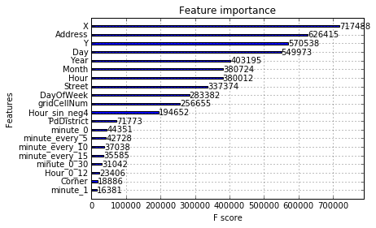

```python
plot_importance(clf.booster())
```

### 5. Тестирование

О том, что надо скормить своему классификатору тестовую выборку.

```python
filename = 'mybest.csv'
```

#### 5.1. Загрузка и константы тестовой выборки

#### 5.2. Обработка тестовой выборки

#### 5.3. Предсказания классификатора

Пропускаем тестовую выборку через свой классификатор и записываем результаты в файл.

```python
# pred = clf.predict()
```

```python
# write_results(filename, pred)
```

## submit_to_azure

```python
from io import BytesIO
from azureml.serialization import (
    DataTypeIds,
    deserialize_dataframe,
    serialize_dataframe,
    is_supported,
)

def save_csv_to_Azure(data, workspace_id, authorization_token, name, description):
    rc = _RestClient('https://studioapi.azureml.net', authorization_token)
    output = BytesIO()
    serialize_dataframe(output, 'GenericCSV', submit_data)
    raw_data = output.getvalue()
    output.close()

    rc.upload_dataset(workspace_id=workspace_id,
                      name=name,
                      description=description,
                      data_type_id='GenericCSV',
                      raw_data=raw_data,
                      family_id=None)
```

```python
import json
import requests
from azureml.errors import AzureMLConflictHttpError

try:
    from urlparse import urljoin
except ImportError:
    from urllib.parse import urljoin

from azureml.errors import (
    AzureMLHttpError,
)

__author__ = 'Microsoft Corp. <ptvshelp@microsoft.com>'
__version__ = '0.2.6'


class _RestClient(object):
    SERVICE_ROOT = 'api/'
    INTERMEDIATE_DATASET_URI_FMT = SERVICE_ROOT + 'workspaces/{0}/experiments/{1}/outputdata/{2}/{3}'
    EXPERIMENTS_URI_FMT = SERVICE_ROOT + 'workspaces/{0}/experiments'
    DATASOURCES_URI_FMT = SERVICE_ROOT + 'workspaces/{0}/datasources'
    DATASOURCE_URI_FMT = SERVICE_ROOT + 'workspaces/{0}/datasources/{1}'
    UPLOAD_URI_FMI = SERVICE_ROOT + 'resourceuploads/workspaces/{0}/?userStorage=true&dataTypeId={1}'
    UPLOAD_CHUNK_URI_FMT = SERVICE_ROOT + 'blobuploads/workspaces/{0}/?numberOfBlocks={1}&blockId={2}&uploadId={3}&dataTypeId={4}'
    SESSION_ID_HEADER_NAME = 'x-ms-client-session-id'
    SESSION_ID_HEADER_VALUE = 'DefaultSession'
    ACCESS_TOKEN_HEADER_NAME = 'x-ms-metaanalytics-authorizationtoken'
    CONTENT_TYPE_HEADER_NAME = 'Content-Type'
    CONTENT_TYPE_HEADER_VALUE_JSON = 'application/json;charset=UTF8'
    CHUNK_SIZE = 0x200000
    DEFAULT_OWNER = 'Python SDK'
    USER_AGENT_HEADER_NAME = 'User-Agent'
    USER_AGENT_HEADER_VALUE = 'pyazureml/' + __version__

    def __init__(self, service_endpoint, access_token):
        self._service_endpoint = service_endpoint
        self._access_token = access_token

    def get_experiments(self, workspace_id):
        """Runs HTTP GET request to retrieve the list of experiments."""
        api_path = self.EXPERIMENTS_URI_FMT.format(workspace_id)
        return self._send_get_req(api_path)

    def get_datasets(self, workspace_id):
        """Runs HTTP GET request to retrieve the list of datasets."""
        api_path = self.DATASOURCES_URI_FMT.format(workspace_id)
        return self._send_get_req(api_path)

    def get_dataset(self, workspace_id, dataset_id):
        """Runs HTTP GET request to retrieve a single dataset."""
        api_path = self.DATASOURCE_URI_FMT.format(workspace_id, dataset_id)
        return self._send_get_req(api_path)

    def open_intermediate_dataset_contents(self, workspace_id, experiment_id,
                                           node_id, port_name):
        return self._get_intermediate_dataset_contents(
            workspace_id,
            experiment_id,
            node_id,
            port_name,
            stream=True).raw

    def read_intermediate_dataset_contents_binary(self, workspace_id,
                                                  experiment_id, node_id,
                                                  port_name):
        return self._get_intermediate_dataset_contents(
            workspace_id,
            experiment_id,
            node_id,
            port_name,
            stream=False).content

    def read_intermediate_dataset_contents_text(self, workspace_id,
                                                experiment_id, node_id,
                                                port_name):
        return self._get_intermediate_dataset_contents(
            workspace_id,
            experiment_id,
            node_id,
            port_name,
            stream=False).text

    def _get_intermediate_dataset_contents(self, workspace_id, experiment_id,
                                           node_id, port_name, stream):
        api_path = self.INTERMEDIATE_DATASET_URI_FMT.format(
            workspace_id, experiment_id, node_id, port_name)
        response = requests.get(
            url=urljoin(self._service_endpoint, api_path),
            headers=self._get_headers(),
            stream=stream,
        )
        return response

    def open_dataset_contents(self, url):
        response = requests.get(url, stream=True)
        return response.raw

    def read_dataset_contents_binary(self, url):
        response = requests.get(url)
        return response.content

    def read_dataset_contents_text(self, url):
        response = requests.get(url)
        return response.text

    def upload_dataset(self, workspace_id, name, description, data_type_id,
                       raw_data, family_id):
        # uploading data is a two step process. First we upload the raw data
        api_path = self.UPLOAD_URI_FMI.format(workspace_id, data_type_id)
        upload_result = self._send_post_req(api_path, data=b'')

        # now get the id that was generated
        upload_id = upload_result["Id"]

        # Upload the data in chunks...
        total_chunks = int((len(raw_data) + (self.CHUNK_SIZE-1)) / self.CHUNK_SIZE)
        for chunk in range(total_chunks):
            chunk_url = self.UPLOAD_CHUNK_URI_FMT.format(
                workspace_id,
                total_chunks, # number of blocks
                chunk, # block id
                upload_id,
                data_type_id,
            )
            chunk_data = raw_data[chunk*self.CHUNK_SIZE:(chunk + 1)*self.CHUNK_SIZE]
            self._send_post_req(chunk_url, data=chunk_data)

        # use that to construct the DataSource metadata
        metadata = {
            "DataSource": {
                "Name": name,
                "DataTypeId":data_type_id,
                "Description":description,
                "FamilyId":family_id,
                "Owner": self.DEFAULT_OWNER,
                "SourceOrigin":"FromResourceUpload"
            },
            "UploadId": upload_id,
            "UploadedFromFileName":"",
            "ClientPoll": True
        }

        try:
            api_path = self.DATASOURCES_URI_FMT.format(workspace_id)
        except AzureMLConflictHttpError as e:
            raise AzureMLConflictHttpError(
                'A data set named "{}" already exists'.format(name),
                e.status_code
            )

        datasource_id = self._send_post_req(
            api_path, json.dumps(metadata), self.CONTENT_TYPE_HEADER_VALUE_JSON)
        return datasource_id

    def _send_get_req(self, api_path):
        response = requests.get(
            url=urljoin(self._service_endpoint, api_path),
            headers=self._get_headers()
        )

        if response.status_code >= 400:
            raise AzureMLHttpError(response.text, response.status_code)

        return response.json()

    def _send_post_req(self, api_path, data, content_type=None):
        response = requests.post(
            url=urljoin(self._service_endpoint, api_path),
            data=data,
            headers=self._get_headers(content_type)
        )

        if response.status_code >= 400:
            raise AzureMLHttpError(response.text, response.status_code)

        return response.json()

    def _get_headers(self, content_type=None):
        headers = {
            self.USER_AGENT_HEADER_NAME: self.USER_AGENT_HEADER_VALUE,
            self.CONTENT_TYPE_HEADER_NAME: self.CONTENT_TYPE_HEADER_VALUE_JSON,
            self.SESSION_ID_HEADER_NAME: self.SESSION_ID_HEADER_VALUE,
            self.ACCESS_TOKEN_HEADER_NAME: self._access_token
        }
        if content_type:
            headers[self.CONTENT_TYPE_HEADER_NAME] = content_type
        return headers
```